# Adjustment of Labor Markets to Robots | Journal of the European Economic Association | Oxford Academic

### 2.4. Descriptive Overview

Table 1 provides a descriptive overview of the data for the local labor market analysis. The average region saw a slight decline in employment. When weighting by the number of full-time equivalent jobs in 1994, this decline becomes sharper, which demonstrates that larger regions declined more strongly.<sup>17</sup> The overall decline stems mostly from the declining manufacturing sector, which has not been compensated by growth of non-manufacturing industries. Wages (deflated to 2,010 euros) have increased on average, but more strongly in the manufacturing sector than in other sectors. These insights are also reflected in the changes of the total wage bill (the product of employment and wage) and the *E/POP*.

Table 1.

Summary statistics, region level, 1994–2014.

| Observations | Unweighted 402 Mean | Unweighted 402 (SD) | Weighted 23,884,076 Mean | Weighted 23,884,076 (SD) |
| --- | --- | --- | --- | --- |
| **[A] Outcomes** |  |  |  |  |
| % change in total employment | −1.048 | (17.944) | −2.923 | (15.854) |
| % change in manufacturing employment | −9.716 | (25.432) | −16.859 | (23.710) |
| % change in non-manufuring employment | 4.736 | (22.406) | 3.737 | (20.723) |
| 100 × ln-change in average wage | 32.640 | (10.022) | 32.751 | (9.468) |
| 100 × ln-change in average wage, manufacturing | 40.033 | (15.692) | 40.479 | (14.178) |
| 100 × ln-change in average wage, non-manufacturing | 28.922 | (11.731) | 29.536 | (11.143) |
| 100 × ln-change in total wage bill | 37.076 | (18.774) | 36.236 | (16.832) |
| 100 × ln-change in total wage bill, manufuring | 33.004 | (32.597) | 26.152 | (31.625) |
| 100 × ln-change in total wage bill, non-manufacturing | 38.184 | (20.795) | 39.073 | (19.610) |
| Percentage point change in *E/POP* | −0.369 | (3.643) | −1.131 | (3.549) |
| Percentage point change in *E/POP*, manufacturing | −0.851 | (2.328) | −1.417 | (2.285) |
| Percentage point change in *E/POP*, non-manufacturing | 0.482 | (3.281) | 0.286 | (3.294) |
| 100 × ln-change in GDP per worker | 46.529 | (21.149) | 43.455 | (19.419) |
| **[B] Control variables** |  |  |  |  |
| % female | 34.715 | (4.674) | 35.155 | (4.706) |
| % foreign | 6.981 | (4.782) | 8.071 | (5.147) |
| % age ≥ 50 years | 20.101 | (2.366) | 21.192 | (2.450) |
| % unskilled | 11.063 | (4.435) | 10.794 | (4.218) |
| % vocational training | 80.296 | (4.117) | 78.220 | (4.851) |
| % university degree | 7.956 | (3.965) | 10.154 | (4.592) |
| % manufacturing | 30.473 | (12.559) | 27.773 | (12.880) |
| % food products | 3.443 | (2.076) | 2.814 | (1.752) |
| % consumer goods | 4.609 | (4.012) | 3.876 | (3.494) |
| % industrial goods | 11.846 | (7.516) | 10.491 | (7.725) |
| % capital goods | 11.048 | (8.733) | 11.069 | (8.315) |
| % construction | 13.562 | (4.717) | 12.514 | (4.773) |
| % maintenance: hotel and catering | 19.231 | (4.469) | 19.594 | (4.193) |
| % services | 14.186 | (5.271) | 17.908 | (7.864) |
| % public sector | 19.913 | (6.397) | 19.963 | (6.312) |
| dummy, 1 = north | 0.159 | (0.366) | 0.149 | (0.357) |
| dummy, 1 = south | 0.348 | (0.477) | 0.282 | (0.451) |
| dummy, 1 = east | 0.192 | (0.394) | 0.230 | (0.421) |
| Δ net exports in 1,000 euros per worker | 0.956 | (3.146) | 1.002 | (2.758) |
| Δ ICT equipment in euros per worker | 661.942 | (157.081) | 733.603 | (185.298) |
| **[C] Predicted exposure to robots** |  |  |  |  |
| Δ predicted robot exposure | 4.617 | (8.028) | 4.642 | (7.808) |
| p10–p90 interval | [0.982; 8.527] |  | [0.982; 8.527] |  |
| p25–p75 interval | [1.438; 4.540] |  | [1.394; 5.108] |  |

Notes: Summary statistics of region-level variables. In columns 3 and 4, the data are weighted by full-time-equivalent number of jobs in 1994. The variable of interest is the change in predicted robot exposure per 1,000 workers between 1994 and 2014.

Sources: IFR, COMTRADE, EU KLEMS, BEH V10.01.00, and BHP 7514 v1, own calculations.

[Open in new tab](https://academic.oup.com/view-large/325292905)

Table 1.

Summary statistics, region level, 1994–2014.

[output not shown]

Notes: Summary statistics of region-level variables. In columns 3 and 4, the data are weighted by full-time-equivalent number of jobs in 1994. The variable of interest is the change in predicted robot exposure per 1,000 workers between 1994 and 2014.

Sources: IFR, COMTRADE, EU KLEMS, BEH V10.01.00, and BHP 7514 v1, own calculations.

[Open in new tab](https://academic.oup.com/view-large/325292905)

Panel B of this table presents averages and standard deviations of control variables. We control for the shares of women, foreigners, workers older than 50, and workers with a college degree, as well as the employment shares of nine broad industry categories. In our empirical analysis, we also disentangle robots from two other major economic shocks that have affected Germany since the beginning of the 1990s: the increasing international trade with China and Eastern Europe and increasing investments in information and communications technology (ICT). Both may have contributed (positively or negatively) to the probability of displacement for workers, thus leading to heterogeneous wage and employment effects for different individuals. We therefore use data from the UN Comtrade database and EU KLEMS on industry-level net exports and ICT investment, respectively, to construct two further shift-share variables, which both have positive averages.<sup>18</sup>

Finally, we report the means and deciles of the measure of predicted robot exposure in panel C. In the average region, the predicted number of robots has increased by around 4.6 robots per 1,000 workers. However, as shown in Figure 2, the distribution is skewed to the right, with a handful of very large values.

### 2.5. Regressions Models

In Sections 3–5, we estimate the following model at the local labor market level:

(2)

We regress a change—sometimes a percentage change—of an outcome variable, such as total employment, manufacturing employment, or *E/POP*, over the period 1994–2014, on the change in the predicted number of robots per worker (i.e. on as defined in equation (1)). In the vector we control for detailed demographic characteristics of the local workforce (such as age, gender, and qualification) in levels, aggregated up from the universe of individual social security records. To avoid contamination by the endogenous adjustment of the local labor force after the shock, we use levels before the start of the periods rather than changes. We also include the employment shares of nine broadly defined industry groups, four broad region dummies, and the predicted local exposures to net exports and ICT usage.

As discussed in Section 2.3, for inference, we apply the method proposed by Adão, Kolesár, and Morales (2019). In the tables, we label them shift-share standard errors. We additionally present conventional standard errors, using 50 clusters that represent a higher geographical aggregation of local labor markets.<sup>19</sup> On average, the shift-share standard errors tend to be larger, thus making inference more conservative.

### 2.6. Balancing Tests

We conduct several balancing tests on how important regional economic indicators in the base year are correlated with predicted robot exposure between 1994 and 2014. Although our model specification should filter out long-run level differences between regions, it is informative to gauge if other regional characteristics might be confounded with predicted automation.

Panel A of Table 2 shows the coefficients when five different baseline variables from 1994 are regressed on predicted robot exposure and a constant. Robot-exposed labor markets tend to have a slightly higher income (GDP) per capita. (However, the standard error is relatively large when using the inference suggested by Adão, Kolesár, and Morales (2019).) The unemployment rate and skill shares are not associated with future predicted robot exposure. The last column shows a strong association with the relative size of the manufacturing sector, but this should not be surprising: Almost all automation analyzed in this paper happens in the manufacturing sector, as discussed in Section 2.2. Nonetheless, it becomes clear why controlling for sectoral employment shares in local labor markets is important.<sup>20</sup> In further robustness checks, we additionally control for pre-trends in manufacturing sector growth and not only for the initial levels.

Table 2.

Balancing tests for regional characteristics in 1994.

|  | Dependent variable: ln(GDP capita) (1) | Dependent variable: % unemployment rate (2) | Dependent variable: % high skilled (3) | Dependent variable: % un-skilled (4) | Dependent variable: % manufacturing employment (5) |
| --- | --- | --- | --- | --- | --- |
| **[A] Unconditional** |  |  |  |  |  |
| ▵ predicted robot exposure | 0.0099 | −0.0153 | −0.0335 | 0.0685 | 0.6580 |
|  | (0.002) | (0.035) | (0.022) | (0.039) | (0.076) |
|  | [0.010] | [0.040] | [0.039] | [0.042] | [0.464] |
| *R*<sup>2</sup> | 0.067 | 0.002 | 0.005 | 0.017 | 0.204 |
| **[B] Conditional on full controls** |  |  |  |  |  |
| ▵ predicted robot exposure | −0.0018 | 0.0119 |  |  |  |
|  | (0.003) | (0.023) |  |  |  |
|  | [0.002] | [0.033] |  |  |  |
| *R*<sup>2</sup> | 0.779 | 0.682 |  |  |  |

Notes: *N* = 402 local labor market regions (*Landkreise und kreisfreie Staedte*, GDP data not available for the two East German regions Eisenach and Wartburgkreis). 2SLS IV regressions, where German-predicted robot exposure is instrumented with robot installations across industries in other high-income countries. Each entry represents the coefficient of a regression of the respective variable on the change in predicted robot exposure per 1,000 workers between 1994 and 2014. All specifications include a constant. In panel B, we control for broad region dummies [west (reference), north, south, or east], employment shares of female, foreign, age ≥50, medium-skilled (with completed apprenticeship), and high-skilled (with a university degree) workers relative to total employment (reference category: unskilled workers and with unknown education), broad industry shares [agriculture (reference), food products, consumer goods, industrial goods, capital goods, construction, consumer-related services, business-related services, public sector], and the change in German net exports vis-à-vis China and 21 Eastern European countries (in 1,000 euros per worker) and the change in ICT equipment (in euros per worker), both between 1994 and 2014. Standard errors clustered at the level of 50 aggregate labor market regions in parentheses. Shift-share standard errors in brackets.

Sources: IFR, Comtrade, EU KLEMS, BEH V10.01.00, and BHP 7514 v1, own calculations.

[Open in new tab](https://academic.oup.com/view-large/325292915)

Table 2.

Balancing tests for regional characteristics in 1994.

[output not shown]

Notes: *N* = 402 local labor market regions (*Landkreise und kreisfreie Staedte*, GDP data not available for the two East German regions Eisenach and Wartburgkreis). 2SLS IV regressions, where German-predicted robot exposure is instrumented with robot installations across industries in other high-income countries. Each entry represents the coefficient of a regression of the respective variable on the change in predicted robot exposure per 1,000 workers between 1994 and 2014. All specifications include a constant. In panel B, we control for broad region dummies [west (reference), north, south, or east], employment shares of female, foreign, age ≥50, medium-skilled (with completed apprenticeship), and high-skilled (with a university degree) workers relative to total employment (reference category: unskilled workers and with unknown education), broad industry shares [agriculture (reference), food products, consumer goods, industrial goods, capital goods, construction, consumer-related services, business-related services, public sector], and the change in German net exports vis-à-vis China and 21 Eastern European countries (in 1,000 euros per worker) and the change in ICT equipment (in euros per worker), both between 1994 and 2014. Standard errors clustered at the level of 50 aggregate labor market regions in parentheses. Shift-share standard errors in brackets.

Sources: IFR, Comtrade, EU KLEMS, BEH V10.01.00, and BHP 7514 v1, own calculations.

[Open in new tab](https://academic.oup.com/view-large/325292915)

In panel B, we present the coefficients on future predicted robot exposure when including our set of control variables in the regressions. The skill shares and sectoral employment shares are among our set of controls, which is why these variables drop out. The coefficient in column (1) is now very close to zero in the log income regression, and the coefficient in the unemployment regression stays small in magnitude. In Appendix Table A.1, we additionally go further back in time and present the conditional correlation of similar regional indicators in 1978 and 1984 with future predicted robot exposure. The results are unaffected and only the relative size of the manufacturing sector is associated with future predicted exposure to automation, once control variables are taken into account.<sup>21</sup>

## 3. Baseline Effects

In this section, we present our baseline results for the impact of robots on employment, wages, wage bills, and *E/POP*s, and we conduct a number of robustness checks.

### 3.1. Employment Effects

In Table 3, we first look at employment changes in percentage terms, using ordinary least-squares (OLS) regressions in panel A.<sup>22</sup> We include a separate row for the shift-share standard errors using the method proposed by Adão, Kolesár, and Morales (2019) while reporting the conventional standard errors (allowing for 50 regional clusters) in parentheses below the estimates.

Table 3.

Robot exposure and employment.

|  | Dependent variable: % change in total employment between 1994 and 2014 (1) | Dependent variable: % change in total employment between 1994 and 2014 (2) | Dependent variable: % change in total employment between 1994 and 2014 (3) | Dependent variable: % change in total employment between 1994 and 2014 (4) |
| --- | --- | --- | --- | --- |
| **[A] OLS** |  |  |  |  |
| ▵ predicted robot exposure | 0.0541 | −0.0357 | −0.0635 | 0.0866 |
|  | (0.107) | (0.126) | (0.122) | (0.122) |
|  | [0.088] | [0.119] | [0.121] | [0.163] |
| *R*<sup>2</sup> | 0.503 | 0.567 | 0.571 | 0.583 |
| **[B] 2SLS** |  |  |  |  |
| ▵ predicted robot exposure | 0.0675 | −0.0519 | −0.0780 | 0.0686 |
|  | (0.106) | (0.133) | (0.129) | (0.137) |
|  | [0.084] | [0.136] | [0.136] | [0.177] |
| % manufacturing | −0.0992 |  |  |  |
|  | (0.166) |  |  |  |
| % food products |  | 2.4866 | 2.4577 | 2.3962 |
|  |  | (0.460) | (0.459) | (0.438) |
| % consumer goods |  | 0.4806 | 0.5593 | 0.5320 |
|  |  | (0.314) | (0.319) | (0.305) |
| % industrial goods |  | 0.5793 | 0.5487 | 0.5418 |
|  |  | (0.278) | (0.285) | (0.267) |
| % capital goods |  | 0.9418 | 0.9051 | 0.9130 |
|  |  | (0.273) | (0.284) | (0.264) |
| % construction |  | 1.0271 | 1.0108 | 1.0287 |
|  |  | (0.295) | (0.298) | (0.279) |
| % consumer services |  | 1.4895 | 1.4837 | 1.6150 |
|  |  | (0.354) | (0.359) | (0.347) |
| % business services |  | 0.4554 | 0.4495 | 0.8158 |
|  |  | (0.294) | (0.295) | (0.269) |
| % public sector |  | 0.9016 | 0.8935 | 1.0742 |
|  |  | (0.271) | (0.273) | (0.260) |
| ▵ net exports in 1,000 euros per worker |  |  | 0.3879 | 0.3743 |
|  |  |  | (0.218) | (0.216) |
| ▵ ICT equipment in 1,000 euros per worker |  |  |  | −0.0245 |
|  |  |  |  | (0.007) |
| Kleibergen–Paap weak ID test | 562.668 | 391.407 | 383.098 | 378.041 |
| Hansen J *P*-value | 0.426 | 0.235 | 0.227 | 0.210 |

Notes: *N* = 402 local labor market regions (*Landkreise und kreisfreie Staedte*). Regressions of total employment growth (in %) on the change in predicted robot exposure per 1,000 workers between 1994 and 2014. All specifications include a constant and broad region dummies indicating if the region is located in the north, west, south, or east of Germany and demographic control variables, measured in the base year 1994. The demographic control variables are the employment shares of female, foreign, age ≥50, medium-skilled (with completed apprenticeship), and high-skilled (with a university degree) workers relative to total employment (reference category: unskilled workers and with unknown education). In column (1), we control for the manufacturing share in total employment. In columns (2)–(4), we instead include broad industry shares to control better for regional industry patterns. Industry shares cover the percentage of workers in nine broad industry groups [agriculture (reference), food products, consumer goods, industrial goods, capital goods, construction, consumer-related services, business-related services, and public sector) in the base year 1994. Columns (3) and (4) successively take into account the change in German net exports vis-à-vis China and 21 Eastern European countries (in 1,000 euros per worker) and the change in ICT equipment (in euros per worker), both between 1994 and 2014. Panel B reports results of a 2SLS IV approach where German-predicted robot exposure is instrumented with robot installations across industries in other high-income countries. Standard errors clustered at the level of 50 aggregate labor market regions in parentheses. Shift-share standard errors in brackets.

Sources: IFR, Comtrade, EU KLEMS, BEH V10.01.00, and BHP 7514 v1, own calculations.

[Open in new tab](https://academic.oup.com/view-large/325292921)

Table 3.

Robot exposure and employment.

[output not shown]

Notes: *N* = 402 local labor market regions (*Landkreise und kreisfreie Staedte*). Regressions of total employment growth (in %) on the change in predicted robot exposure per 1,000 workers between 1994 and 2014. All specifications include a constant and broad region dummies indicating if the region is located in the north, west, south, or east of Germany and demographic control variables, measured in the base year 1994. The demographic control variables are the employment shares of female, foreign, age ≥50, medium-skilled (with completed apprenticeship), and high-skilled (with a university degree) workers relative to total employment (reference category: unskilled workers and with unknown education). In column (1), we control for the manufacturing share in total employment. In columns (2)–(4), we instead include broad industry shares to control better for regional industry patterns. Industry shares cover the percentage of workers in nine broad industry groups [agriculture (reference), food products, consumer goods, industrial goods, capital goods, construction, consumer-related services, business-related services, and public sector) in the base year 1994. Columns (3) and (4) successively take into account the change in German net exports vis-à-vis China and 21 Eastern European countries (in 1,000 euros per worker) and the change in ICT equipment (in euros per worker), both between 1994 and 2014. Panel B reports results of a 2SLS IV approach where German-predicted robot exposure is instrumented with robot installations across industries in other high-income countries. Standard errors clustered at the level of 50 aggregate labor market regions in parentheses. Shift-share standard errors in brackets.

Sources: IFR, Comtrade, EU KLEMS, BEH V10.01.00, and BHP 7514 v1, own calculations.

[Open in new tab](https://academic.oup.com/view-large/325292921)

Column (1) presents a parsimonious specification with the initial manufacturing and regional dummies as the only additional control variables. The estimated effect is positive, but very small and statistically insignificant. Quantitatively, comparing a local labor market at the 75th percentile of predicted robot exposure to a local labor market at the 25th percentile, the magnitudes imply that the highly exposed market experiences 0.155% point ([4.540 − 1.438] × 0.05 = 0.155) higher employment growth, which translates into roughly 100 additional (full-time equivalent) jobs for an average region.

The estimates remain small and statistically insignificant as we enrich the specifications. First, we include the initial employment shares of nine broad industry groups instead of the overall manufacturing share, as there may be more fine-grained industry trends (correlated with employment outcomes and robot installations) within the manufacturing sector. Yet, the coefficient in column (2) stays close to zero.

Column (3) adds the predicted trade exposure of local labor markets, using exports and imports with Eastern Europe and China, as described in Section 2.4.<sup>23</sup> Column (4) additionally includes predicted exposure to ICT investments. The inclusion of both variables clearly has a visible effect on the main coefficient, moving its magnitude by around 0.03 and 0.15 points. However, the main results remain unaffected, and the coefficient estimates imply only small employment effects of automation.

Panel B shows the results when the regressions are estimated with 2SLS. First, across the different specifications, the 2SLS estimates are close to their OLS counterparts. The Kleibergen and Paap (2006) statistic indicates there is no problem of weak instruments, and the Hansen test values imply no rejection of the null hypothesis of valid instruments. For the remainder of this paper, we will focus on the IV estimates; the corresponding OLS estimates are shown in the Online Appendix.

### 3.2. Displacement versus Re-allocation

#### 3.2.1. Manufacturing and Services

We next study the displacement and re-allocation/productivity effects of automation separately. To analyze decomposition effects, we opt for (arguably) the most transparent cut of the data. In particular, the displacement of workers should occur within the robot-adopting manufacturing sector. At the same time, the demand for labor in all other local industries increases when industries are gross complements in the production of a final consumption good. A plausible hypothesis is thus that service industries should see an increase in labor demand.

Table 4.

Composition effects.

|  | Total (1) | Manufacturing (2) | Manufacturing (3) | Manufacturing (4) | Non-manufacturing (5) | Non-manufacturing (6) | Non-manufacturing (7) |
| --- | --- | --- | --- | --- | --- | --- | --- |
| **[A] Employment**: % change in total employment between 1994 and 2014 |  |  |  |  |  |  |  |
| ▵ predicted robot exposure | 0.0686 | −0.5938 | −0.6212 | −0.4663 | 0.5847 | 0.5638 | 0.7243 |
|  | (0.137) | (0.166) | (0.158) | (0.160) | (0.325) | (0.321) | (0.327) |
|  | [0.177] | [0.314] | [0.311] | [0.293] | [0.394] | [0.401] | [0.458] |
| **[B] *E/POP***: 100 × ▵ in employment/population between 1994 and 2014 |  |  |  |  |  |  |  |
| ▵ predicted robot exposure | 0.0084 | −0.0512 | −0.0557 | −0.0479 | 0.0457 | 0.0445 | 0.0563 |
|  | (0.062) | (0.025) | (0.025) | (0.027) | (0.046) | (0.046) | (0.046) |
|  | [0.031] | [0.034] | [0.033] | [0.030] | [0.037] | [0.038] | [0.044] |
| Effect of one robot | 0.3 | −1.8 | −2.0 | −1.7 | 1.6 | 1.6 | 2.0 |
| **[C] Wages**: 100 × log-▵ in average wage between 1994 and 2014) |  |  |  |  |  |  |  |
| ▵ predicted robot exposure | −0.0402 | −0.1459 | −0.1540 | −0.1116 | 0.0912 | 0.0834 | 0.0929 |
|  | (0.045) | (0.051) | (0.052) | (0.066) | (0.042) | (0.042) | (0.042) |
|  | [0.031] | [0.082] | [0.083] | [0.079] | [0.062] | [0.061] | [0.064] |
| **[D] Wage bill**: 100 × log-▵ in total wage bill on June 30 |  |  |  |  |  |  |  |
| ▵ predicted robot exposure | 0.0568 | −0.6980 | −0.7414 | −0.5245 | 0.4428 | 0.4176 | 0.5742 |
|  | (0.153) | (0.173) | (0.164) | (0.201) | (0.251) | (0.248) | (0.254) |
|  | [0.207] | [0.366] | [0.363] | [0.356] | [0.316] | [0.322] | [0.384] |
| ▵ net exports in 1,000euros per worker | Yes | No | Yes | Yes | No | Yes | Yes |
| ▵ ICT equipment in eurosper worker | Yes | No | No | Yes | No | No | Yes |

Notes: 2SLS IV regressions, where German-predicted robot exposure is instrumented with robot installations across industries in other high-income countries. In all regressions, the variable of interest is the change in predicted robot exposure per 1,000 workers between 1994 and 2014. The estimates in panels A, B, and D are based on *N* = 402 local labor market regions (*Landkreise und kreisfreie Staedte*), while the unit of observation in the wage estimates in panel C is *N* = 7,235 regions × demographic cells. Demographic cells are defined by gender, three age groups, and three education groups. We only include cells containing at least ten observations, and perform the regressions at the region × demographic cell level including fixed effects for demographic cells. The dependent variable in panel D is the log-difference total amount of gross salaries paid to employees subject to social security on June 30 in 1994 and 2014. All specifications include a constant, broad region dummies, demographic control variables, and employment shares of nine aggregate industry groups, measured in the base year 1994. Standard errors clustered at the level of 50 aggregate labor market regions in parentheses. Shift-share standard errors in brackets.

Sources: IFR, Comtrade, EU KLEMS, BEH V10.01.00, and BHP 7514 v1, own calculations.

[Open in new tab](https://academic.oup.com/view-large/325292930)

Table 4.

Composition effects.

[output not shown]

Notes: 2SLS IV regressions, where German-predicted robot exposure is instrumented with robot installations across industries in other high-income countries. In all regressions, the variable of interest is the change in predicted robot exposure per 1,000 workers between 1994 and 2014. The estimates in panels A, B, and D are based on *N* = 402 local labor market regions (*Landkreise und kreisfreie Staedte*), while the unit of observation in the wage estimates in panel C is *N* = 7,235 regions × demographic cells. Demographic cells are defined by gender, three age groups, and three education groups. We only include cells containing at least ten observations, and perform the regressions at the region × demographic cell level including fixed effects for demographic cells. The dependent variable in panel D is the log-difference total amount of gross salaries paid to employees subject to social security on June 30 in 1994 and 2014. All specifications include a constant, broad region dummies, demographic control variables, and employment shares of nine aggregate industry groups, measured in the base year 1994. Standard errors clustered at the level of 50 aggregate labor market regions in parentheses. Shift-share standard errors in brackets.

Sources: IFR, Comtrade, EU KLEMS, BEH V10.01.00, and BHP 7514 v1, own calculations.

[Open in new tab](https://academic.oup.com/view-large/325292930)

In panel C, we repeat the analysis using the change in local average daily log wages as the outcome variable. We note that the wage estimates must be interpreted with some caution. Predicted robot exposure displaces workers at least in the manufacturing sector, which creates selection since wage outcomes are only available for employed workers.<sup>26</sup> We circumvent those selection issues in Section 6, when we look at labor earnings directly for exposed individual workers. The results, by and large, mirror the employment effects. Column (1) shows a small, negative, and insignificant impact of predicted robot exposure on wage growth. Consistent with the employment results, however, we see negative effects within manufacturing in columns (2)–(4), and positive effects in the service sector in columns (5)–(7). The results strongly support the hypothesis of decreased manufacturing labor demand in regions with higher predicted robot exposure, and an offsetting increase in labor demand for local services.

Panel D combines the wage and employment information by calculating sectoral total wage bills (based on the universe of social security records). The results in columns (1)–(7) strongly support the interpretation of reduced manufacturing labor demand in regions strongly exposed to automation, but increasing labor demand in local service industries.

The results represent evidence that the adoption of robots has led to *positive employment spillovers* on other local industries in non-manufacturing.<sup>27</sup> Our data allow us to further look at this channel. Appendix Table A.4 presents estimates when we split up the non-manufacturing sector into several subsectors. We differentiate business services, consumer services, construction, and the public sector. The first category includes employment in establishments that render their services to other businesses on a contractual basis. This includes ICT, cleaning, or security. The second category, consumer services, contains hotels and restaurants, as well as beauty services such as haircutting.

By far the largest employment effect is on business services with a coefficient of 0.638. The consumer service coefficient, in contrast, is only estimated to have a value of 0.051. The other coefficients on construction employment and public sector employment are close to zero. Positive employment spillovers are, hence, driven by spending from local firms on local services. This result is consistent with the model by Acemoglu and Restrepo (2019), where increased robot adoption raises demand for complementarity inputs by producers. Relatedly, Goldschmidt and Schmieder (2017) show that task outsourcing has increased within Germany. It is conceivable that increased automation may be related to changing boundaries of the firm, and may accelerate these processes. This would be consistent with a positive effect of automation on business service employment.

The Appendix contains important robustness checks to our findings (Appendix Table A.2). After repeating our baseline results, we first check for the presence of pre-trends by regressing lagged outcome variables on future exposure.<sup>28</sup> Second, we restrict the time window for the analysis to stop before the global great recession in 2007. Third, we include “marginal workers”. Those very low-paying part-time jobs are only covered in the social security data starting in 1999. In this robustness check, we include this group in the worker counts at the end of our observation period, and count them as zero in the beginning of the period. It turns out that our main results are not affected. Next, we conduct various checks concerning the regional dimensions. Leaving out East Germany does not change the results. They also remain very similar when we include time trends at the level of 16 federal states. Another robustness check is to use different regional aggregations to define local labor markets. We change the boundaries, making labor markets broader (reducing the number of units from 402 to 258 labor market areas used for the “joint task of the federal government and the states for the improvement of regional economic structures” (GRW) or to 141 commuting zones delineated by Kosfeld and Werner 2012). We observe the same pattern of displacement and re-allocation, although imprecision increases when the sample size decreases.

Finally, we pay special attention to the car industry, which plays a dominant role in the German economy and is highly robotized. We split up the treatment variable into predicted exposure to robots in automobile production and to robots in other industries. The displacement effect is relatively homogeneous across sectors. Re-allocation is driven by the predicted exposure to robots in automobile production, in contrast. This suggests that the productivity effects were particularly large in this sector.<sup>29</sup> An alternative way to look at the automotive sector is to distinguish between automotive and other manufacturing when constructing the outcome variables, as we show in panel H. While the effect of robots on other manufacturing industries is quantitatively similar to the overall effect, we find an exorbitant but also very imprecisely estimated negative coefficient for car manufacturing. We conclude that our main results are not exclusively driven by this sector, but are rather representative for manufacturing as a whole.

#### 3.2.2. Effects within Manufacturing and Task Shares

So far, we have looked at displacement and re-allocation at the sectoral level. An additional way to split the data is to separate employment effects within manufacturing. In particular, predicted robot exposure will plausibly have different effects on routine versus non-routine jobs even within the sector. Table 5 shows the results for such a sample split within manufacturing, using employment growth as a dependent variable. Comparing columns (1) and (4) from panel A, one can see how the displacement effect is more pronounced for routine jobs (coefficients −0.466 and −0.660), as expected. The point estimate for non-routine jobs from column (7) is much smaller but also negative (−0.266) and statistically insignificant. As before, panel B shows the results using *E/POP*s as a dependent variable. The coefficients in columns (4) and (7) add to the total effect in column (1). In contrast to panel A, the point estimate from column (7) on non-routine jobs is positive in this specification, but also statistically insignificant.<sup>30</sup> These results are not totally conclusive on the strength of re-allocation within the sector.

Table 5.

Composition effects: routine versus non-routine intensive manufacturing.

|  | Total (1) | Routine (2) | Routine (3) | Routine (4) | Non-Routine (5) | Non-Routine (6) | Non-Routine (7) |
| --- | --- | --- | --- | --- | --- | --- | --- |
| **[A] Employment**: % change in total employment between 1994 and 2014 |  |  |  |  |  |  |  |
| ▵ predicted robot exposure | −0.4663 | −0.7920 | −0.7785 | −0.6601 | −0.3773 | −0.4531 | −0.2656 |
|  | (0.160) | (0.218) | (0.205) | (0.223) | (0.240) | (0.233) | (0.236) |
|  | [0.293] | [0.447] | [0.447] | [0.423] | [0.312] | [0.278] | [0.283] |
| **[B] *E*/*POP***: 100 × ▵ in employment/population between 1994 and 2014 |  |  |  |  |  |  |  |
| ▵ predicted robot exposure | −0.0479 | −0.0692 | −0.0683 | −0.0662 | 0.0180 | 0.0126 | 0.0183 |
|  | (0.027) | (0.024) | (0.024) | (0.026) | (0.037) | (0.037) | (0.039) |
|  | [0.030] | [0.043] | [0.043] | [0.041] | [0.022] | [0.020] | [0.021] |
| Effect of one robot | −1.7 | −2.4 | −2.4 | −2.3 | 0.6 | 0.4 | 0.6 |
| ▵ net exports in 1,000 euros per worker | Yes | No | Yes | Yes | No | Yes | Yes |
| ▵ ICT equipment in euros per worker | Yes | No | No | Yes | No | No | Yes |

Notes: 2SLS IV regressions, where German-predicted robot exposure is instrumented with robot installations across industries in other high-income countries. In all regressions, the variable of interest is the change in predicted robot exposure per 1,000 workers between 1994 and 2014. The estimates in panels A and B are based on *N* = 402 local labor market regions (*Landkreise und kreisfreie Staedte*), while the unit of observation in the wage estimates in panel C is *N* = 7,217 regions × demographic cells. Demographic cells are defined by gender, three age groups, and three education groups. We only include cells containing at least ten observations, and perform the regressions at the region × demographic cell level including fixed effects for demographic cells. All specifications include a constant, broad region dummies, demographic control variables, and employment shares of nine aggregate industry groups, measured in the base year 1994. Routine intensive is defined as being employed in an occupation that ranks above the 66th percentile of the share of routine tasks relative to all tasks (see Spitz-Oener 2006; Autor and Dorn 2013). Standard errors clustered at the level of 50 aggregate labor market regions in parentheses. Shift-share standard errors in brackets.

Sources: IFR, Comtrade, EU KLEMS, BEH V10.01.00, and BHP 7514 v1, own calculations.

[Open in new tab](https://academic.oup.com/view-large/325292940)

Table 5.

Composition effects: routine versus non-routine intensive manufacturing.

[output not shown]

Notes: 2SLS IV regressions, where German-predicted robot exposure is instrumented with robot installations across industries in other high-income countries. In all regressions, the variable of interest is the change in predicted robot exposure per 1,000 workers between 1994 and 2014. The estimates in panels A and B are based on *N* = 402 local labor market regions (*Landkreise und kreisfreie Staedte*), while the unit of observation in the wage estimates in panel C is *N* = 7,217 regions × demographic cells. Demographic cells are defined by gender, three age groups, and three education groups. We only include cells containing at least ten observations, and perform the regressions at the region × demographic cell level including fixed effects for demographic cells. All specifications include a constant, broad region dummies, demographic control variables, and employment shares of nine aggregate industry groups, measured in the base year 1994. Routine intensive is defined as being employed in an occupation that ranks above the 66th percentile of the share of routine tasks relative to all tasks (see Spitz-Oener 2006; Autor and Dorn 2013). Standard errors clustered at the level of 50 aggregate labor market regions in parentheses. Shift-share standard errors in brackets.

Sources: IFR, Comtrade, EU KLEMS, BEH V10.01.00, and BHP 7514 v1, own calculations.

[Open in new tab](https://academic.oup.com/view-large/325292940)

We obtain clearer results, however, when estimating a version of the empirical model, which uses changes in the task utilization within manufacturing directly. In Table 6, the dependent variable is the percentage point change in the share of routine/abstract/manual tasks relative to all tasks in manufacturing in a local labor market. Columns (1) and (2) document the shift in the task composition of manufacturing sector jobs associated with automation. The estimates imply almost an exact offset for the routine and abstract task shares. Later in Section 5, we build on those results, and show that predicted robot exposure is also strongly associated with occupational transitions of routine job workers into occupations with a higher abstract task share, for those workers who are retained by their original employers.

Table 6.

Composition effects: change in task intensity.

|  | (1) Routine | (2) Abstract | (3) Manual |
| --- | --- | --- | --- |
| **Manufacturing** |  |  |  |
| ▵ predicted robot exposure | −0.0939 | 0.0815 | 0.0109 |
|  | (0.024) | (0.039) | (0.031) |
|  | [0.064] | [0.061] | [0.019] |

Notes: 2SLS IV regressions, where German-predicted robot exposure is instrumented with robot installations across industries in other high-income countries. In all regressions, the variable of interest is the change in predicted robot exposure per 1,000 workers between 1994 and 2014. The dependent variable is the percentage point change in the share of routine/abstract/manual tasks relative to all tasks. Task intensity is measured at the level of occupations according to the BIBB/BAuA Survey in 1991. The estimates are based *N* = 402 local labor market regions (*Landkreise und kreisfreie Staedte*). The regressions include the full set of control variables as in column (4) of Table 3. Standard errors clustered at the level of 50 aggregate labor market regions in parentheses. Shift-share standard errors in brackets.

Sources: IFR, Comtrade, EU KLEMS, BEH V10.01.00, and BHP 7514 v1, own calculations.

[Open in new tab](https://academic.oup.com/view-large/325292942)

Table 6.

Composition effects: change in task intensity.

|  | (1) Routine | (2) Abstract | (3) Manual |
| --- | --- | --- | --- |
| **Manufacturing** |  |  |  |
| ▵ predicted robot exposure | −0.0939 | 0.0815 | 0.0109 |
|  | (0.024) | (0.039) | (0.031) |
|  | [0.064] | [0.061] | [0.019] |

Notes: 2SLS IV regressions, where German-predicted robot exposure is instrumented with robot installations across industries in other high-income countries. In all regressions, the variable of interest is the change in predicted robot exposure per 1,000 workers between 1994 and 2014. The dependent variable is the percentage point change in the share of routine/abstract/manual tasks relative to all tasks. Task intensity is measured at the level of occupations according to the BIBB/BAuA Survey in 1991. The estimates are based *N* = 402 local labor market regions (*Landkreise und kreisfreie Staedte*). The regressions include the full set of control variables as in column (4) of Table 3. Standard errors clustered at the level of 50 aggregate labor market regions in parentheses. Shift-share standard errors in brackets.

Sources: IFR, Comtrade, EU KLEMS, BEH V10.01.00, and BHP 7514 v1, own calculations.

[Open in new tab](https://academic.oup.com/view-large/325292942)

## 4. Adjust Mechanism I: Reduced Creation of New Jobs for Young Workers

We have documented the presence of substantial displacement and re-allocation effects of automation by using a local labor market approach. In this section, we leverage the availability of detailed administrative panel data to understand better which kinds of workers are actually displaced and reallocated in response to automation. One of the main results will highlight that a large portion of the incidence of displacement and re-allocation is borne by young workers, who face reduced (increased) job creation in the manufacturing (service) sector. However, as an important qualifier, this does not imply that young workers only bear the costs of labor market adjustments and are left behind by automation. In Section 5, we will show that as a response to predicted robot exposure, labor market entrants also are more likely to attend college and hold jobs that are more abstract and less routine intensive. This suggests that net-welfare effect for young entrants could plausibly also be positive. In addition, it should be clarified that re-allocation for young workers only happens in a counterfactual sense, as they start their careers in the service sector instead of manufacturing.

We analyze the adjustment process by decomposing the employment variables from Section 3 into mutually exclusive channels. The decomposition is additive and, hence, easy to interpret. We start by characterizing the displacement effect. Conceptually, we distinguish between workers who were working in the exposed manufacturing sector at the start of the observation period in 1994 and non-incumbents who were not working in manufacturing.

Table 7.

Adjustment.

| Same plant as in 1994 Same sector as in 1994 | Dependent variable: 100 × number of workers in 2014/total employment in 1994 Incumbent workers Yes (1) | Dependent variable: 100 × number of workers in 2014/total employment in 1994 Incumbent workers No Yes (2) | Dependent variable: 100 × number of workers in 2014/total employment in 1994 Entrants Entered labor market after 1994 (3) | Dependent variable: 100 × number of workers in 2014/total employment in 1994 Entrants Same region, different sector in 1994 (4) | Dependent variable: 100 × number of workers in 2014/total employment in 1994 Entrants In different region in 1994 (5) | Dependent variable: 100 × number of workers in 2014/total employment in 1994 Entrants Not employed in 1994 (6) | Dependent variable: 100 × number of workers in 2014/total employment in 1994 Total (7) |
| --- | --- | --- | --- | --- | --- | --- | --- |
| **[A] Manufacturing** |  |  |  |  |  |  |  |
| ▵ predicted robot exposure | 0.1723 | −0.2503 | −0.2473 | −0.0493 | −0.0040 | −0.0877 | −0.4663 |
|  | (0.051) | (0.051) | (0.089) | (0.027) | (0.040) | (0.025) | (0.160) |
|  | [0.080] | [0.123] | [0.141] | [0.044] | [0.063] | [0.041] | [0.293] |
| **[B] Non-Manufacturing** |  |  |  |  |  |  |  |
| ▵ predicted robot exposure | −0.0504 | −0.0376 | 0.5676 | −0.0153 | 0.2101 | 0.0499 | 0.7243 |
|  | (0.014) | (0.027) | (0.230) | (0.013) | (0.059) | (0.046) | (0.327) |
|  | [0.030] | [0.027] | [0.348] | [0.006] | [0.113] | [0.039] | [0.458] |

Notes: *N* = 402.2SLS IV regressions, where German-predicted robot exposure is instrumented with robot installations across industries in other high-income countries. In this table, the employment growth rate is additively split up into the contributions of different groups of incumbent workers or workers that enter the region’s manufacturing (panel A) or non-manufacturing sector (panel B) between 1994 and 2014. The coefficients of columns (1)–(6) sum up to the coefficient in column 7. In all regressions, the variable of interest is the change in predicted robot exposure per 1,000 workers between 1994 and 2014. The regressions include the full set of control variables as in column (4) of Table 3. Standard errors clustered at the level of 50 aggregate labor market regions in parentheses. Shift-share standard errors in brackets.

Sources: IFR, COMTRADE, EU KLEMS, BEH V10.01.00, and BHP 7514 v1, own calculations.

[Open in new tab](https://academic.oup.com/view-large/325292947)

Table 7.

Adjustment.

[output not shown]

Notes: *N* = 402.2SLS IV regressions, where German-predicted robot exposure is instrumented with robot installations across industries in other high-income countries. In this table, the employment growth rate is additively split up into the contributions of different groups of incumbent workers or workers that enter the region’s manufacturing (panel A) or non-manufacturing sector (panel B) between 1994 and 2014. The coefficients of columns (1)–(6) sum up to the coefficient in column 7. In all regressions, the variable of interest is the change in predicted robot exposure per 1,000 workers between 1994 and 2014. The regressions include the full set of control variables as in column (4) of Table 3. Standard errors clustered at the level of 50 aggregate labor market regions in parentheses. Shift-share standard errors in brackets.

Sources: IFR, COMTRADE, EU KLEMS, BEH V10.01.00, and BHP 7514 v1, own calculations.

[Open in new tab](https://academic.oup.com/view-large/325292947)

Column (1) in panel A starts with a—perhaps—surprising finding. Predicted exposure to automation increases employment at one’s original employer. The effect is sizable and around a third of the total displacement effect from column (7). We will devote parts of the next section to explain the mechanisms, and document how workers relocate within firms across tasks and occupations. While incumbent workers face a lower layoff risk, this is offset by decreased employment in other firms in manufacturing, as evidenced by the estimate in column (2).<sup>33</sup>

These two findings are consistent with the following interpretation(s). Labor market institutions in the form of firing costs make it costly to lay off workers even though the tasks previously performed by those workers are now carried out by industrial robots. At the same time, productivity effects are plausibly occurring mostly within the same firms adopting robots, which allows the re-shuffling of workers from automated tasks to other tasks, since the new demand for non-automated tasks arises in those firms. These two forces explain why robot adoption actually increases employment within the original plant. In Section 5, we document how automation is related to the re-shuffling of workers across tasks within plants. In addition, below, we present (indirect) evidence on how variation in labor market institutions influences the retainment effect from column (1). However, the estimate in column (2) shows that—conditional on a separation—workers have a harder time regaining employment in similar industries, consistent with the general reduced labor demand in robot-adopting industries. This leads to reduced employment in the manufacturing sector for incumbent workers.

The main part of the displacement incidence falls on non-incumbent workers, however. The negative coefficient in column (3) reveals that the largest burden falls on young workers, who had not entered the labor market in 1994 (and subsequently entered in some year between 1995 and 2014). Automation also reduces flows from the service into the manufacturing sector and lowers entry from unemployment, as evidenced by columns (4) and (6). The effect sizes, however, are much smaller compared to the entrant margin. Reduced netmigration, as measured by column (5), plays no role in explaining the displacement force.

Panel B provides the same decomposition for the non-manufacturing sector to study the re-allocation effect. By construction, the sum of columns (1)–(6) equals the estimate from column (7) (and column (7) from Table 4). We expect zero or only very small impacts for non-manufacturing incumbent workers, since their task set is not exposed to automation. This is confirmed in columns (1) and (2). An important open question is if the manufacturing displacement experienced by entering labor market cohorts leads to offsetting gains for young workers in services. The estimate in column (3) provides the answer and implies gains for young workers. The larger coefficient in panel B combined with the larger denominator of the outcome implies that those gains overcompensate the adverse impacts from displacement. If productivity effects also spill over into the service sector—something that should be expected, given that tasks in this sector are complements to automated tasks—predicted robot exposure should presumably also increase labor demand in services at other margins. There is indeed a positive effect—shown in column (5) of panel B—on pulling in workers into an expanding service sector from other regions.

Given that the incidence of the re-allocation effect falls primarily on young workers, one should expect that the age structure in the manufacturing sector evolves differently from that in the service sector. In Appendix Table A.5, we find that automation reduces the average age of workers in the service sector and increases the average age of manufacturing workers (although the latter effect is small and imprecisely estimated). Our results are consistent with a two-way interaction between automation and aging. Acemoglu and Restrepo (2018a) investigate the effect of an older population on more automation. We find that more automation leads to an increase in the average age of the working population in more affected regions. These effects could reinforce each other.

### 4.1. Heterogeneity by Unionization Rates

In this subsection, we present additional results for the displacement and re-allocation effects, splitting labor markets into the relative strengths of trade unions.<sup>34</sup> We are not explicit about specific mechanisms how regional union strength affects outcomes directly. Rather, we interpret it as a proxy for different labor market institutions strengthening incumbent workers’ rights. Examples include higher wage bargaining power, more powerful work councils, which are deeply involved in organizational decisions at the firm level and can negotiate deviations from collective bargaining arrangements in order to prevent mass layoffs, and so forth. Net trade union density rates, measured as the fraction of workers who are union members, at the regional level are calculated using the German Social Economic Panel (GSOEP) in the year 1993.<sup>35</sup> To illustrate heterogeneous impacts, we split local labor markets into either a high or low worker protection group.<sup>36</sup> The results do not necessarily reflect the causal effect of union density, since we cannot rule out that those groups also differ in other dimensions, such as local preferences. However, we gain confidence since controlling for federal-state fixed effects does not change the results qualitatively.

Above in this section, we presented a worker retention result: Workers in more exposed local labor markets are more likely to stay with their original plant. Are firms retaining their workers voluntarily at higher rates in the wake of automation, because they value their firm-specific human capital? Or does this finding capture high firing costs? We try to examine this in Table 8. Comparing the coefficients in column (1) from panels A and B reveals that the retention effect is twice as large in areas with higher worker protection. At least part of the retention, therefore, seems to reflect institutional constraints on firms to adjust to technological change. In contrast, conditional on leaving the original plant, workers are not protected by these institutions any more. Consistent with this, column (2) shows that the effects of robots on mobility to other plants within the manufacturing sector do not differ between regions with higher and lower job protection. In columns (3)–(6), we again report the effects on entrants into the local manufacturing sector. Aside from the lower retention of incumbent workers, the manufacturing sector in low job protection regions also attracts fewer young entrants, formerly unemployed, and workers changing between sectors. In total, column (7) shows that the displacement effect measured by manufacturing employment was much stronger in environments with low worker protection.

Table 8.

Manufacturing adjustment—by shares of union members (SOEP).

| Same plant as in 1994 Same sector as in 1994 | Dependent variable: 100 × number of workers in 2014/total employment in 1994 Incumbent workers Yes (1) | Dependent variable: 100 × number of workers in 2014/total employment in 1994 Incumbent workers No Yes (2) | Dependent variable: 100 × number of workers in 2014/total employment in 1994 Entrants Entered labor market after 1994 (3) | Dependent variable: 100 × number of workers in 2014/total employment in 1994 Entrants Same region, different sector in 1994 (4) | Dependent variable: 100 × number of workers in 2014/total employment in 1994 Entrants In different region in 1994 (5) | Dependent variable: 100 × number of workers in 2014/total employment in 1994 Entrants Not employed in 1994 (6) | Dependent variable: 100 × number of workers in 2014/total employment in 1994 Total (7) |
| --- | --- | --- | --- | --- | --- | --- | --- |
| **[A] Above median share of union members** |  |  |  |  |  |  |  |
| ▵ predicted robot exposure | 0.2567 | −0.2596 | −0.1322 | −0.0570 | 0.0183 | −0.0823 | −0.2561 |
|  | (0.069) | (0.050) | (0.130) | (0.050) | (0.047) | (0.043) | (0.248) |
|  | [0.121] | [0.130] | [0.138] | [0.060] | [0.074] | [0.042] | [0.280] |
| **[B] Below median share of union members** |  |  |  |  |  |  |  |
| ▵ predicted robot exposure | 0.1281 | −0.2908 | −0.4217 | −0.0557 | −0.0111 | −0.1028 | −0.7540 |
|  | (0.084) | (0.109) | (0.179) | (0.026) | (0.098) | (0.062) | (0.371) |
|  | [0.077] | [0.120] | [0.262] | [0.063] | [0.132] | [0.094] | [0.543] |

Notes: *N* = 199 (panel A) and 203 (panel B). 2SLS IV regressions, where German-predicted robot exposure is instrumented with robot installations across industries in other high-income countries. In this table, the employment growth rate is additively split up into the contributions of different groups of incumbent workers or workers that enter the region’s manufacturing sector between 1994 and 2014. The coefficients of columns (1)–(6) sum up to the coefficient in column (7). In all regressions, the variable of interest is the change in predicted robot exposure per 1,000 workers between 1994 and 2014. The regressions include the full set of control variables as in column (4) of Table 3. Standard errors clustered at the level of 50 aggregate labor market regions in parentheses. Shift-share standard errors in brackets.

Sources: IFR, COMTRADE, EU KLEMS, BEH V10.01.00, and BHP 7514 v1, and SOEP, own calculations.

[Open in new tab](https://academic.oup.com/view-large/325292956)

Table 8.

Manufacturing adjustment—by shares of union members (SOEP).

[output not shown]

Notes: *N* = 199 (panel A) and 203 (panel B). 2SLS IV regressions, where German-predicted robot exposure is instrumented with robot installations across industries in other high-income countries. In this table, the employment growth rate is additively split up into the contributions of different groups of incumbent workers or workers that enter the region’s manufacturing sector between 1994 and 2014. The coefficients of columns (1)–(6) sum up to the coefficient in column (7). In all regressions, the variable of interest is the change in predicted robot exposure per 1,000 workers between 1994 and 2014. The regressions include the full set of control variables as in column (4) of Table 3. Standard errors clustered at the level of 50 aggregate labor market regions in parentheses. Shift-share standard errors in brackets.

Sources: IFR, COMTRADE, EU KLEMS, BEH V10.01.00, and BHP 7514 v1, and SOEP, own calculations.

[Open in new tab](https://academic.oup.com/view-large/325292956)

## 5. Adjust Mechanism II: Skill Upgrading

In this section, we turn our attention to different mechanisms of adjustment: the re-assignment of workers to new tasks and the upgrading of skills. The analysis will establish four new results. First, a majority of workers who are retained by their firms in the wake of automation are re-assigned to new occupations. Second, their new occupations feature more abstract and less routine intensive task contents. Third, they are higher up in the wage ladder, and are characterized by a higher college share. Finally, the skill (college) share among labor market entrants increases significantly, the apprentice share goes down, and the jobs held by labor market entrants become more abstract and less routine intensive.

Table 9 presents the results from models that analyze the adjustment process for incumbent manufacturing workers. They all follow the specification with the most comprehensive set of control variables, as in Sections 3 and 4. Our linked employer–employee data allow us to observe the workplace of every worker at all points in time. We also observe three-digit occupation codes, which we aggregate to 54 economically more meaningful occupational fields according to the German Federal Institute for Vocational Education and Training (Tiemann et al. 2008). We measure the quality of occupations according to four dimensions: the median wage of all full-time employees, the share of workers with a college degree, and the intensity in abstract and routine tasks. For the latter two, we follow Spitz-Oener (2006) and construct task intensities as the average shares of abstract or routine tasks in all tasks performed by around 20,000 workers surveyed in the 1991 BIBB/IAB Employment Survey.<sup>37</sup>

Table 9.

Occupational upgrading within and across firms.

|  | (1) | (2) | (3) | (4) |
| --- | --- | --- | --- | --- |
| **[A] Occupational adjustment** |  |  |  |  |
|  | Dependent variable: |  |  |  |
|  | 100 × number of workers in 2014/ |  |  |  |
|  | total employment in 1994 |  |  |  |
| Same plant as in 1994 | Yes | Yes | Yes |  |
| Same occupation as in 1994 | Yes | No | (total) |  |
| ▵ predicted robot exposure | 0.0437 | 0.1287 | 0.1723 |  |
|  | (0.027) | (0.030) | (0.051) |  |
|  | [0.025] | [0.062] | [0.080] |  |
| **[B] Occupational upgrading: wages and skills** |  |  |  |  |
|  | Dependent variables: |  |  |  |
|  | ▵ log median wage in euros |  | 100 × ▵ college share |  |
| Same plant as in 1994 | Yes | No | Yes | No |
| ▵ predicted robot exposure | 0.0633 | 0.0258 | 0.0583 | 0.0146 |
|  | (0.024) | (0.032) | (0.024) | (0.022) |
|  | [0.046] | [0.035] | [0.039] | [0.016] |
| **[C] Occupational upgrading: tasks** |  |  |  |  |
|  | Dependent variables: |  |  |  |
|  | 100 × ▵ abstract task intensity |  | 100 × ▵ routine task intensity |  |
| Same plant as in 1994 | Yes | No | Yes | No |
| ▵ predicted robot exposure | 0.0719 | −0.0227 | −0.1229 | −0.0470 |
|  | (0.025) | (0.023) | (0.028) | (0.026) |
|  | [0.045] | [0.019] | [0.077] | [0.031] |

Notes: *N* = 402. 2SLS IV regressions, where German-predicted robot exposure is instrumented with robot installations across industries in other high-income countries. In this table, we analyze the effect of robots on the occupation dimension of exposed workers. In panel A, the dependent variables are 100 × the number of workers who stay in the manufacturing sector of their original region but show different kinds of job mobility, relative to total employment in 1994. The coefficients of panel A, columns (1) and (2), add up to the coefficient in column (1) of panel A, Table 7 [also reported in column (3)]. In panels B and C, we focus on the occupational quality of workers who stay in the manufacturing sector of their original region but possibly switch into a different occupation. The dependent variable in columns (1) and (2) of panel B is the average difference of the median wage, measured in 1994, of the occupation of workers staying in the same plant in 2014 versus the occupation in 1994. The dependent variable in columns (3) and (4) of Panel B is the average difference of the percentage of people with a college degree (measured in 1994) of the occupation of workers staying in the same plant in 2014 versus the same percentage of those workers' occupation in 1994. The dependent variable in panel C is the average difference of the abstract (columns (1) and (2)) and routine (columns (3) and (4)) task intensities, measured in 1994, and of the occupation of workers staying in the same plant in 2014 versus the occupation in 1994. In all regressions, the variable of interest is the change in predicted robot exposure per 1,000 workers between 1994 and 2014. The regressions include the full set of control variables as in column (4) of Table 3. Standard errors clustered at the level of 50 aggregate labor market regions in parentheses. Shift-share standard errors in brackets.

Sources: IFR, COMTRADE, EU KLEMS, BEH V10.01.00, and BHP 7514 v1, own calculations.

[Open in new tab](https://academic.oup.com/view-large/325292960)

Table 9.

Occupational upgrading within and across firms.

|  | (1) | (2) | (3) | (4) |
| --- | --- | --- | --- | --- |
| **[A] Occupational adjustment** |  |  |  |  |
|  | Dependent variable: |  |  |  |
|  | 100 × number of workers in 2014/ |  |  |  |
|  | total employment in 1994 |  |  |  |
| Same plant as in 1994 | Yes | Yes | Yes |  |
| Same occupation as in 1994 | Yes | No | (total) |  |
| ▵ predicted robot exposure | 0.0437 | 0.1287 | 0.1723 |  |
|  | (0.027) | (0.030) | (0.051) |  |
|  | [0.025] | [0.062] | [0.080] |  |
| **[B] Occupational upgrading: wages and skills** |  |  |  |  |
|  | Dependent variables: |  |  |  |
|  | ▵ log median wage in euros |  | 100 × ▵ college share |  |
| Same plant as in 1994 | Yes | No | Yes | No |
| ▵ predicted robot exposure | 0.0633 | 0.0258 | 0.0583 | 0.0146 |
|  | (0.024) | (0.032) | (0.024) | (0.022) |
|  | [0.046] | [0.035] | [0.039] | [0.016] |
| **[C] Occupational upgrading: tasks** |  |  |  |  |
|  | Dependent variables: |  |  |  |
|  | 100 × ▵ abstract task intensity |  | 100 × ▵ routine task intensity |  |
| Same plant as in 1994 | Yes | No | Yes | No |
| ▵ predicted robot exposure | 0.0719 | −0.0227 | −0.1229 | −0.0470 |
|  | (0.025) | (0.023) | (0.028) | (0.026) |
|  | [0.045] | [0.019] | [0.077] | [0.031] |

Notes: *N* = 402. 2SLS IV regressions, where German-predicted robot exposure is instrumented with robot installations across industries in other high-income countries. In this table, we analyze the effect of robots on the occupation dimension of exposed workers. In panel A, the dependent variables are 100 × the number of workers who stay in the manufacturing sector of their original region but show different kinds of job mobility, relative to total employment in 1994. The coefficients of panel A, columns (1) and (2), add up to the coefficient in column (1) of panel A, Table 7 [also reported in column (3)]. In panels B and C, we focus on the occupational quality of workers who stay in the manufacturing sector of their original region but possibly switch into a different occupation. The dependent variable in columns (1) and (2) of panel B is the average difference of the median wage, measured in 1994, of the occupation of workers staying in the same plant in 2014 versus the occupation in 1994. The dependent variable in columns (3) and (4) of Panel B is the average difference of the percentage of people with a college degree (measured in 1994) of the occupation of workers staying in the same plant in 2014 versus the same percentage of those workers' occupation in 1994. The dependent variable in panel C is the average difference of the abstract (columns (1) and (2)) and routine (columns (3) and (4)) task intensities, measured in 1994, and of the occupation of workers staying in the same plant in 2014 versus the occupation in 1994. In all regressions, the variable of interest is the change in predicted robot exposure per 1,000 workers between 1994 and 2014. The regressions include the full set of control variables as in column (4) of Table 3. Standard errors clustered at the level of 50 aggregate labor market regions in parentheses. Shift-share standard errors in brackets.

Sources: IFR, COMTRADE, EU KLEMS, BEH V10.01.00, and BHP 7514 v1, own calculations.

[Open in new tab](https://academic.oup.com/view-large/325292960)

Panel A starts with a decomposition of the retainment effect, shedding light on the question how plants keep workers around in the wake of automation. Column (3) repeats this retainment effect from column (1) of Table 7. In columns (1) and (2), the coefficient is additively decomposed into the contribution of days employed *in the same plant* in a worker’s original occupation in 1994 and of days employed in other occupations by defining the dependent variables in this way. The magnitudes imply that 75% (0.1287/0.1723) of the total effect stems from days worked in a different occupation.

It is not clear yet to what extent workers profit from those occupational transitions. To address this, the next set of models in panels B and C investigates several dimensions of the occupational quality of jobs. All dependent variables in these two panels are constructed as follows: First, we measure the quality of each occupation in terms of either wage, education, or task intensity. Second, for each worker who stays in the manufacturing sector of her or his original region, we calculate the difference in occupational quality between 1994 and 2014. Third, we average those individual-level differences over all workers in each region.

The first measure is the change in median occupational wages. Concretely, we measure the quality of an occupation at any point in time as the median wage of all workers in this occupation in 1994.<sup>38</sup> The outcome variable is the average log-difference of the median wage of the occupation a worker held in 2014 versus the median wage of the occupation the same worker held in 1994. In column (1) of panel B, this variable is constructed only from workers who stayed in their initial plant, while in column (2) the outcome is analogously defined for workers who switched between plants. Positive coefficients would indicate that predicted robot exposure leads to occupational upgrading. Column (1) displays a positive coefficient, around twice the size of the coefficient in column (2). So, on average, higher predicted robot exposure is associated with occupational mobility up the wage ladder, and the effect is much stronger within plants, that is, for workers who were retained by their original employer.

In column (3) of panel B, we measure the quality of an occupation at any point in time as the percentage of workers with a college degree in 1994. The dependent variable is average of the difference in the college share of the occupation a worker held in 2014 versus the college percentage of the same worker’s occupation in 1994.<sup>39</sup> The results imply a positive effect of automation on occupational quality,<sup>40</sup> and the comparison with column (4) shows that the effect is again much larger for firm stayers.<sup>41</sup>

Finally, panel C studies the re-assignment of tasks for exposed workers. The dependent variable in panel C is the average difference of the abstract (columns (1) and (2)) and routine (columns (3) and (4)) task intensities, measured in 1994, of the occupation of workers in 2014 versus their occupation in 1994. Columns (1) and (3) present evidence that automation seems to cause a shift in the careers of workers away from routine and toward abstract tasks within plants. The coefficients in columns (2) and (4) show much smaller effects across plants.

We next turn to human capital adjustments of young cohorts. The first dependent variable of Table 10 is the change in the share of college-educated workers aged 30 or lower. To be included, workers need to hold a degree that requires at least three years of tertiary education. The positive coefficient indicates that young people adjust to local automation by increasing their level of education. Column (2) shows that is counteracted by a significant reduction in the apprenticeship share. Importantly, the table also shows that the adjustment efforts of young workers extend beyond educational and into occupational choices. In columns (3) and (4), we measure the effect of robots on changes in the task contents of jobs held by people below age 30. In more robot exposed regions, we observe a stronger re-allocation from routine toward abstract tasks. These results are robust to using different age cutoffs from 30; in Appendix Table A.3, we present the results with an age cutoff of 40 as an example.

Table 10.

Robots and skill share of people younger than 30.

|  | Dependent variable: 100 × ▵ Share of workers with: University degree (1) | Dependent variable: 100 × ▵ Share of workers with: Apprenticeship degree (2) | Dependent variable: Task intensity Abstract (3) | Dependent variable: Task intensity Routine (4) |
| --- | --- | --- | --- | --- |
| ▵ predicted robot exposure | 0.1091 | −0.0876 | 0.0835 | −0.0606 |
|  | (0.048) | (0.038) | (0.036) | (0.023) |
|  | [0.051] | [0.043] | [0.042] | [0.039] |

Notes: 2SLS IV regressions, where German-predicted robot exposure is instrumented with robot installations across industries in other high-income countries. In this table, we analyze the effect of robots on occupational quality of younger workers. The estimates are based on *N* = 402 local labor market regions (*Landkreise und kreisfreie Staedte*). The dependent variable is the change in various measures for occupation quality of workers 30 years old or less between 1994 and 2014: share of workers with a university degree (column (1)), share of workers with an apprenticeship degree (column (2)), average abstract task intensity (column (3)), and average routine task intensity (column (4)). In all regressions, the variable of interest is the change in predicted robot exposure per 1,000 workers between 1994 and 2014. The regressions include the full set of control variables as in column (4) of Table 3. Standard errors clustered at the level of 50 aggregate labor market regions in parentheses. Shift-share standard errors in brackets.

Sources: IFR, COMTRADE, EU KLEMS, BEH V10.01.00, and BHP 7514 v1, own calculations.

[Open in new tab](https://academic.oup.com/view-large/325292967)

Table 10.

Robots and skill share of people younger than 30.

|  | Dependent variable: 100 × ▵ Share of workers with: University degree (1) | Dependent variable: 100 × ▵ Share of workers with: Apprenticeship degree (2) | Dependent variable: Task intensity Abstract (3) | Dependent variable: Task intensity Routine (4) |
| --- | --- | --- | --- | --- |
| ▵ predicted robot exposure | 0.1091 | −0.0876 | 0.0835 | −0.0606 |
|  | (0.048) | (0.038) | (0.036) | (0.023) |
|  | [0.051] | [0.043] | [0.042] | [0.039] |

Notes: 2SLS IV regressions, where German-predicted robot exposure is instrumented with robot installations across industries in other high-income countries. In this table, we analyze the effect of robots on occupational quality of younger workers. The estimates are based on *N* = 402 local labor market regions (*Landkreise und kreisfreie Staedte*). The dependent variable is the change in various measures for occupation quality of workers 30 years old or less between 1994 and 2014: share of workers with a university degree (column (1)), share of workers with an apprenticeship degree (column (2)), average abstract task intensity (column (3)), and average routine task intensity (column (4)). In all regressions, the variable of interest is the change in predicted robot exposure per 1,000 workers between 1994 and 2014. The regressions include the full set of control variables as in column (4) of Table 3. Standard errors clustered at the level of 50 aggregate labor market regions in parentheses. Shift-share standard errors in brackets.

Sources: IFR, COMTRADE, EU KLEMS, BEH V10.01.00, and BHP 7514 v1, own calculations.

[Open in new tab](https://academic.oup.com/view-large/325292967)

## 6. Individual Workers

We now shift the focus from local labor market adjustments to individual workers. This complements the previous models, because it allows to directly study the effects of automation on earnings and wages using a more compelling design. Comparing wage or earnings growth across local labor markets, in contrast, can lead to biased results because automation changes the composition of employed workers. By following the same workers, we can circumvent such selection issues.

### 6.1. Earnings and Employment

#### 6.1.1. Design and Data

We use an exposure to automation design that compares the outcomes of workers who were employed in a manufacturing industry in 1994.<sup>42</sup> We follow the standard practice in the literature and focus on workers with sufficiently high labor force attachment. This means that we restrict the sample to workers who were (i) between 22 and 44 years old, (ii) earned more than the marginal-job threshold, and (iii) had job tenure for at least two years in the base year 1994.<sup>43</sup> Finally, we keep only workers in manufacturing industries that can be matched to the IFR data. The specification is

*Y<sub>ij</sub>* represents the cumulated number of days spent in employment—irrespective of whether employed in a manufacturing or a different sector—over the 1995–2014 period in the first set of regressions. In the vector , we include worker-level controls, measured in the base year 1994: dummies for gender, foreign nationality, three skill categories, and three tenure categories. In addition, we include a full set of age dummies, federal state dummies, and dummies for six plant size groups. We also control for the log of yearly earnings of a worker at the start of the period in 1994.

The term is the change in robot adoption per worker—with the number of workers fixed at the starting level in 1994—in industry *j*. As described in Section 2, the IFR classification allows us to distinguish 20 manufacturing industries. To account for this, we cluster standard errors at the levels of the IFR classification with 20 clusters. is a vector of industry controls with dummies for broad industry groups.<sup>44</sup> It also contains changes in trade exposure at the three-digit level and ICT exposure at the two-digit level.<sup>45</sup>

As for the data in this section, we use a 30% random sample of the Integrated Labor Market Biographies (IEB V12.00.00) of the Institute for Employment Research. These data are similar to those introduced in Section 2.1 but cover the complete employment biographies with daily precision and not only the main observation on June 30.<sup>46</sup> Since East Germany saw a very strong wage growth up until 1995, related to other factors besides automation, we drop workers who were employed there in 1994 in a robustness check. Our results are unaffected, consistent with the analogous robustness checks at the regional level.

Table 11 reports descriptive statistics of the variables used in the worker-level analysis. The average manufacturing worker in our sample has experienced an exposure equal to = 24.4 (see panel C). Notice the large variation across individuals. The worker at the 75th percentile has seen an increase in robot exposure that is almost five times larger than for the worker at the 25th percentile (26.1 versus 5.5 additional robots per 1,000 workers), and the comparison between the 90th and the 10th percentiles is even more dramatic (104.3 versus −2.7). This reflects the extremely skewed distribution of robot installation across industries, which is illustrated in Appendix Figure A.1. The average worker in our sample is employed for 5,980 days during the 20 years after 1994, which amounts to 82% of the duration of this period (7,305 days). We measure the cumulative earnings over the 20-year period in multiples of the worker’s earnings in the base year. If, after adjusting for inflation, a worker earned exactly the base year’s earnings in each year of the period, the outcome would be 1 × 20 × 100 = 2,000. In fact, workers have on average almost exactly retained their base year earnings.

Table 11.

Summary statistics, worker level.

| Observations | 720,562 Mean | 720,562 (SD) |
| --- | --- | --- |
| **[A] Outcomes, cumulated over years following base year** |  |  |
| Days employed | 5,980 | (1,986) |
| Average daily wage | 121.3 | (71.2) |
| 100 × earnings/base year earnings | 1,949.8 | (1,000.3) |
| **[B] Control variables, measured in base year** |  |  |
| Base year earnings | 38,683 | (20,599) |
| Base year average wage | 106.55 | (55.14) |
| Dummy, 1 = female | 0.211 | (0.408) |
| Dummy, 1 = foreign | 0.110 | (0.313) |
| Birth year | 1960 | (6) |
| Dummy, 1 = low skilled | 0.160 | (0.366) |
| Dummy, 1 = medium skilled | 0.751 | (0.432) |
| Dummy, 1 = high skilled | 0.089 | (0.285) |
| Dummy, 1 = tenure 2–4 years | 0.397 | (0.489) |
| Dummy, 1 = tenure 5–9 years | 0.317 | (0.465) |
| Dummy, 1 = tenure ≥10 years | 0.247 | (0.431) |
| Dummy, 1 = plant size ≤ 9 | 0.054 | (0.225) |
| Dummy, 1 = plant size 10–99 | 0.224 | (0.417) |
| Dummy, 1 = plant size 100–499 | 0.289 | (0.453) |
| Dummy, 1 = plant size 500–999 | 0.122 | (0.328) |
| Dummy, 1 = plant size 1000–9999 | 0.225 | (0.418) |
| Dummy, 1 = plant size ≥10000 | 0.084 | (0.277) |
| Dummy, 1 = food products | 0.095 | (0.293) |
| Dummy, 1 = textiles | 0.028 | (0.164) |
| Dummy, 1 = wood, paper products | 0.057 | (0.232) |
| Dummy, 1 = chemicals, plastic products | 0.143 | (0.350) |
| Dummy, 1 = metal products | 0.201 | (0.401) |
| Dummy, 1 = electronics | 0.081 | (0.272) |
| Dummy, 1 = machines, appliances | 0.223 | (0.417) |
| Dummy, 1 = vehicles | 0.172 | (0.377) |
| Δ net exports/wage bill in % | 14.413 | (57.996) |
| Δ ICT equipment in euros per worker | 254.9 | (271.7) |
| **[C] Exposure to robots** |  |  |
| Δ robots per 1,000 workers | 24.400 | (40.119) |
| p10–p90 interval | [−2.721; 104.258] |  |
| p25–p75 interval | [5.547; 26.052] |  |

Notes: Summary statistics of worker-level variables.

Sources: IFR, COMTRADE, EU KLEMS, and IEB V12.00.00, own calculations.

[Open in new tab](https://academic.oup.com/view-large/325292977)

Table 11.

Summary statistics, worker level.

| Observations | 720,562 Mean | 720,562 (SD) |
| --- | --- | --- |
| **[A] Outcomes, cumulated over years following base year** |  |  |
| Days employed | 5,980 | (1,986) |
| Average daily wage | 121.3 | (71.2) |
| 100 × earnings/base year earnings | 1,949.8 | (1,000.3) |
| **[B] Control variables, measured in base year** |  |  |
| Base year earnings | 38,683 | (20,599) |
| Base year average wage | 106.55 | (55.14) |
| Dummy, 1 = female | 0.211 | (0.408) |
| Dummy, 1 = foreign | 0.110 | (0.313) |
| Birth year | 1960 | (6) |
| Dummy, 1 = low skilled | 0.160 | (0.366) |
| Dummy, 1 = medium skilled | 0.751 | (0.432) |
| Dummy, 1 = high skilled | 0.089 | (0.285) |
| Dummy, 1 = tenure 2–4 years | 0.397 | (0.489) |
| Dummy, 1 = tenure 5–9 years | 0.317 | (0.465) |
| Dummy, 1 = tenure ≥10 years | 0.247 | (0.431) |
| Dummy, 1 = plant size ≤ 9 | 0.054 | (0.225) |
| Dummy, 1 = plant size 10–99 | 0.224 | (0.417) |
| Dummy, 1 = plant size 100–499 | 0.289 | (0.453) |
| Dummy, 1 = plant size 500–999 | 0.122 | (0.328) |
| Dummy, 1 = plant size 1000–9999 | 0.225 | (0.418) |
| Dummy, 1 = plant size ≥10000 | 0.084 | (0.277) |
| Dummy, 1 = food products | 0.095 | (0.293) |
| Dummy, 1 = textiles | 0.028 | (0.164) |
| Dummy, 1 = wood, paper products | 0.057 | (0.232) |
| Dummy, 1 = chemicals, plastic products | 0.143 | (0.350) |
| Dummy, 1 = metal products | 0.201 | (0.401) |
| Dummy, 1 = electronics | 0.081 | (0.272) |
| Dummy, 1 = machines, appliances | 0.223 | (0.417) |
| Dummy, 1 = vehicles | 0.172 | (0.377) |
| Δ net exports/wage bill in % | 14.413 | (57.996) |
| Δ ICT equipment in euros per worker | 254.9 | (271.7) |
| **[C] Exposure to robots** |  |  |
| Δ robots per 1,000 workers | 24.400 | (40.119) |
| p10–p90 interval | [−2.721; 104.258] |  |
| p25–p75 interval | [5.547; 26.052] |  |

Notes: Summary statistics of worker-level variables.

Sources: IFR, COMTRADE, EU KLEMS, and IEB V12.00.00, own calculations.

[Open in new tab](https://academic.oup.com/view-large/325292977)

In Table 12, we present a balancing analysis similar to the one at the regional level, where we regress individual worker characteristics at the start of the period (in 1994) on future robot exposure. The first column, labeled unconditional, shows the coefficient when the listed variables at the start of the period are regressed on predicted robot exposure and a constant. Workers with higher earnings and wages seem to be more exposed, although the coefficients are not statistically significant at the 5% level. Demographic characteristics are not strongly associated with robot exposure. In contrast, firm size and job tenure are. In the second column, we include our control variables into the regressions. Naturally, when a variable is the left-hand side variable, all controls that are constructed from that variable are left out in the respective specification.<sup>47</sup> This column shows that foreign and low-skilled workers faced a slightly higher risk of automation, conditional on all other control variables. Plant size again is positively associated with automation exposure.

Table 12.

Balancing checks, worker level.

|  | Unconditional Coefficient | Unconditional (SE) | Conditional Coefficient | Conditional (SE) |
| --- | --- | --- | --- | --- |
| **Manufacturing workers in 1994 (720,562 observations)** |  |  |  |  |
| 100 × ln (base year earnings) | 0.130 | (0.076) | −0.050 | (0.047) |
| 100 × ln (base year average wage) | 12.085 | (7.415) | −6.145 | (4.673) |
| 100 × dummy, 1 = female | −0.067 | (0.042) | 0.056 | (0.041) |
| 100 × dummy, 1 = foreign | 0.027 | (0.021) | 0.040 | (0.015) |
| Birth year | 0.001 | (0.001) | 0.000 | (0.001) |
| 100 × dummy, 1 = low skilled | 0.002 | (0.034) | 0.049 | (0.024) |
| 100 × dummy, 1 = medium skilled | 0.023 | (0.027) | −0.017 | (0.033) |
| 100 × dummy, 1 = high skilled | −0.025 | (0.024) | −0.032 | (0.019) |
| Tenure (in years) | 0.016 | (0.004) | −0.004 | (0.001) |
| 100 × ln (plant size) | 2.614 | (0.710) | 1.684 | (0.801) |

Notes: Coefficients from 2SLS regressions of the respective individual characteristics on Δ robots per 1,000 workers (instrumented with robot installations across industries in other high-income countries). Control variables are log base year earnings and indicator variables for gender, foreign nationality, birth year, educational degree (three categories), tenure (three categories), plant size (six categories), manufacturing industry groups (eight categories), and 16 federal states, excluding the respective dependent variable. Earnings are not included in the regression on wages and vice versa. In the regressions for skills levels, none of the skill-level variables appear on the right-hand side. Standard errors clustered by 20 ISIC Rev. 4 industries in parentheses.

Sources: IFR, COMTRADE, EU KLEMS, and IEB V12.00.00, own calculations.

[Open in new tab](https://academic.oup.com/view-large/325292979)

Table 12.

Balancing checks, worker level.

|  | Unconditional Coefficient | Unconditional (SE) | Conditional Coefficient | Conditional (SE) |
| --- | --- | --- | --- | --- |
| **Manufacturing workers in 1994 (720,562 observations)** |  |  |  |  |
| 100 × ln (base year earnings) | 0.130 | (0.076) | −0.050 | (0.047) |
| 100 × ln (base year average wage) | 12.085 | (7.415) | −6.145 | (4.673) |
| 100 × dummy, 1 = female | −0.067 | (0.042) | 0.056 | (0.041) |
| 100 × dummy, 1 = foreign | 0.027 | (0.021) | 0.040 | (0.015) |
| Birth year | 0.001 | (0.001) | 0.000 | (0.001) |
| 100 × dummy, 1 = low skilled | 0.002 | (0.034) | 0.049 | (0.024) |
| 100 × dummy, 1 = medium skilled | 0.023 | (0.027) | −0.017 | (0.033) |
| 100 × dummy, 1 = high skilled | −0.025 | (0.024) | −0.032 | (0.019) |
| Tenure (in years) | 0.016 | (0.004) | −0.004 | (0.001) |
| 100 × ln (plant size) | 2.614 | (0.710) | 1.684 | (0.801) |

Notes: Coefficients from 2SLS regressions of the respective individual characteristics on Δ robots per 1,000 workers (instrumented with robot installations across industries in other high-income countries). Control variables are log base year earnings and indicator variables for gender, foreign nationality, birth year, educational degree (three categories), tenure (three categories), plant size (six categories), manufacturing industry groups (eight categories), and 16 federal states, excluding the respective dependent variable. Earnings are not included in the regression on wages and vice versa. In the regressions for skills levels, none of the skill-level variables appear on the right-hand side. Standard errors clustered by 20 ISIC Rev. 4 industries in parentheses.

Sources: IFR, COMTRADE, EU KLEMS, and IEB V12.00.00, own calculations.

[Open in new tab](https://academic.oup.com/view-large/325292979)

#### 6.1.2 Results

Table 13.

Individual adjustment to robot exposure (employment).

| **[A] Industry mobility** Same employer | (1) All employers | (2) Manufacturing Yes | (3) Manufacturing No | (4) Service sector No |  |
| --- | --- | --- | --- | --- | --- |
| Δ robots per 1,000 workers | 1.4732 | 8.3594 | −4.4239 | −2.4623 |  |
|  | (1.393) | (1.843) | (2.446) | (1.442) |  |
| **[B] Occupational mobility** | (1) | (2) | (3) | (4) | (5) |
|  | All jobs | Same employer |  | Other employer |  |
| Same occupational field |  | Yes | No | Yes | No |
| Δ robots per 1,000 workers | 1.4732 | 3.4427 | 4.9168 | −6.0282 | −0.8580 |
|  | (1.393) | (1.590) | (1.360) | (1.619) | (0.738) |

Notes: Based on 720,562 workers. 2SLS IV regressions, where German robot exposure is instrumented with robot installations across industries in other high-income countries. The outcome variable is cumulated days of employment. For column (1), employment days are cumulated over all employment spells in the 20 years following the base year. Panel A: For column (2), employment days are cumulated only when they occurred at the original workplace. For the other columns, employment days are cumulated only when they occurred at a different plant in the manufacturing sector (column (3)) or outside the manufacturing sector (column (4)), respectively. Panel B: Employment days are cumulated only when they occurred in the original occupation and workplace (column (2)), in a different occupation but at the original workplace (column (3)), in the original occupation but at a different workplace (column (4)), and in a different occupation and workplace (column (5)), respectively. Control variables are log base year earnings and indicator variables for gender, foreign nationality, birth year, educational degree (three categories), tenure (three categories), plant size (six categories), manufacturing industry groups (eight categories), and 16 federal states. Standard errors are clustered by 20 ISIC Rev. 4 industries in parentheses.

Sources: IFR, Comtrade, EU KLEMS, and IEB V12.00.00, own calculations.

[Open in new tab](https://academic.oup.com/view-large/325292982)

Table 13.

Individual adjustment to robot exposure (employment).

| **[A] Industry mobility** Same employer | (1) All employers | (2) Manufacturing Yes | (3) Manufacturing No | (4) Service sector No |  |
| --- | --- | --- | --- | --- | --- |
| Δ robots per 1,000 workers | 1.4732 | 8.3594 | −4.4239 | −2.4623 |  |
|  | (1.393) | (1.843) | (2.446) | (1.442) |  |
| **[B] Occupational mobility** | (1) | (2) | (3) | (4) | (5) |
|  | All jobs | Same employer |  | Other employer |  |
| Same occupational field |  | Yes | No | Yes | No |
| Δ robots per 1,000 workers | 1.4732 | 3.4427 | 4.9168 | −6.0282 | −0.8580 |
|  | (1.393) | (1.590) | (1.360) | (1.619) | (0.738) |

Notes: Based on 720,562 workers. 2SLS IV regressions, where German robot exposure is instrumented with robot installations across industries in other high-income countries. The outcome variable is cumulated days of employment. For column (1), employment days are cumulated over all employment spells in the 20 years following the base year. Panel A: For column (2), employment days are cumulated only when they occurred at the original workplace. For the other columns, employment days are cumulated only when they occurred at a different plant in the manufacturing sector (column (3)) or outside the manufacturing sector (column (4)), respectively. Panel B: Employment days are cumulated only when they occurred in the original occupation and workplace (column (2)), in a different occupation but at the original workplace (column (3)), in the original occupation but at a different workplace (column (4)), and in a different occupation and workplace (column (5)), respectively. Control variables are log base year earnings and indicator variables for gender, foreign nationality, birth year, educational degree (three categories), tenure (three categories), plant size (six categories), manufacturing industry groups (eight categories), and 16 federal states. Standard errors are clustered by 20 ISIC Rev. 4 industries in parentheses.

Sources: IFR, Comtrade, EU KLEMS, and IEB V12.00.00, own calculations.

[Open in new tab](https://academic.oup.com/view-large/325292982)

A popular narrative is that affected workers will have to be flexible and mobile across tasks and occupations to be “one step ahead” of labor-displacing technologies. Those sets of results first imply that workers in Germany already responded by switching tasks to the rise of industrial robots. Second, the reassignment of workers to new tasks happens frequently within a worker’s original firm.

Table 14 extends the analysis to earnings. These models are an important complement, since they paint a more complete picture about workers’ labor market performance than looking at employment outcomes alone. Following Autor et al. (2014), to create the outcome variable, we accumulate all earnings over the whole period and divide them by average earnings in 1994. The regressions can hence be interpreted as difference-in-differences designs.

Table 14.

Individual adjustment to robot exposure (earnings).

| **[A] Industry mobility** Same employer | (1) All employers | (2) Manufacturing Yes | (3) Manufacturing No | (4) Service sector |  |
| --- | --- | --- | --- | --- | --- |
| Δ robots per 1,000 workers | −0.4233 | 2.1093 | −1.7920 | −0.7406 |  |
|  | (1.113) | (0.722) | (0.988) | (0.493) |  |
| **[B] Occupational mobility** | (1) | (2) | (3) | (4) | (5) |
|  | All jobs | Same employer |  | Other employer |  |
| Same occupational field |  | yes | no | yes | no |
| Δ robots per 1,000 workers | −0.4233 | 0.6128 | 1.4965 | −2.1939 | −0.3388 |
|  | (1.113) | (0.608) | (0.481) | (0.695) | (0.342) |

Notes: Based on 720,562 workers. 2SLS IV regressions, where German robot exposure is instrumented with robot installations across industries in other high-income countries. The outcome variables are 100 × earnings (normalized by earnings in the base year) cumulated over the 20 years following the base year. For column (1), earnings are cumulated over all employment spells in the 20 years following the base year. Panel A: For column (2), earnings are cumulated only when they occurred at the original workplace. For the other columns, employment days are cumulated only when they occurred at a different plant in the manufacturing sector (column (3)) or outside the manufacturing sector (column (4)). Panel B: Employment days are cumulated only when they occurred in the original occupation and workplace (column (2)), in a different occupation but at the original workplace (column (3)), in the original occupation but at a different workplace (4), and in a different occupation and workplace (column (5)). Control variables are log base year earnings and indicator variables for gender, foreign nationality, birth year, educational degree (three categories), tenure (three categories), plant size (six categories), manufacturing industry groups (eight categories), and 16 federal states. Standard errors clustered by 20 ISIC Rev. 4 industries in parentheses.

Sources: IFR, Comtrade, EU KLEMS, and IEB V12.00.00, own calculations.

[Open in new tab](https://academic.oup.com/view-large/325292987)

Table 14.

Individual adjustment to robot exposure (earnings).

| **[A] Industry mobility** Same employer | (1) All employers | (2) Manufacturing Yes | (3) Manufacturing No | (4) Service sector |  |
| --- | --- | --- | --- | --- | --- |
| Δ robots per 1,000 workers | −0.4233 | 2.1093 | −1.7920 | −0.7406 |  |
|  | (1.113) | (0.722) | (0.988) | (0.493) |  |
| **[B] Occupational mobility** | (1) | (2) | (3) | (4) | (5) |
|  | All jobs | Same employer |  | Other employer |  |
| Same occupational field |  | yes | no | yes | no |
| Δ robots per 1,000 workers | −0.4233 | 0.6128 | 1.4965 | −2.1939 | −0.3388 |
|  | (1.113) | (0.608) | (0.481) | (0.695) | (0.342) |

Notes: Based on 720,562 workers. 2SLS IV regressions, where German robot exposure is instrumented with robot installations across industries in other high-income countries. The outcome variables are 100 × earnings (normalized by earnings in the base year) cumulated over the 20 years following the base year. For column (1), earnings are cumulated over all employment spells in the 20 years following the base year. Panel A: For column (2), earnings are cumulated only when they occurred at the original workplace. For the other columns, employment days are cumulated only when they occurred at a different plant in the manufacturing sector (column (3)) or outside the manufacturing sector (column (4)). Panel B: Employment days are cumulated only when they occurred in the original occupation and workplace (column (2)), in a different occupation but at the original workplace (column (3)), in the original occupation but at a different workplace (4), and in a different occupation and workplace (column (5)). Control variables are log base year earnings and indicator variables for gender, foreign nationality, birth year, educational degree (three categories), tenure (three categories), plant size (six categories), manufacturing industry groups (eight categories), and 16 federal states. Standard errors clustered by 20 ISIC Rev. 4 industries in parentheses.

Sources: IFR, Comtrade, EU KLEMS, and IEB V12.00.00, own calculations.

[Open in new tab](https://academic.oup.com/view-large/325292987)

We begin in panel A by studying the effect on earnings from all sources. In contrast to the employment effects, one obtains a negative albeit very small and insignificant point estimate of −0.42. To interpret the coefficient, we calculate the quartile spread again, comparing an industry at the 75th percentile of robot exposure to an industry at the 25th percentile. The implied reduction in earnings (over the whole 20 year period and *not* per year) would be 8.7% of annual initial earnings, equivalent to around 3,357 euros in absolute terms for the average worker.

In Appendix Table A.6, we also replicate our main results using lagged outcome variables, showing how individual employment and earnings outcomes from the pre-period 1978-1994 correlated with future robot exposure. Naturally, they are for the most part different workers from those used in the main analysis (i.e. those being in manufacturing in 1978). Total employment is positively correlated with future robot exposure already in the pre-period with a coefficient of similar magnitude. But, importantly, future robots do not correlate with increased employment at one’s original employer. There are also no effects of future robot exposure on transitions within or out of manufacturing. Next, one can see that occupational transitions within the original employment spell are increased in the main analysis, but there is only weak evidence for this in the placebo. Finally, there is no evidence of a pre-trend in employment in the same occupation at a different firm, but a strong reduction in the main specification.<sup>49</sup>

### 6.2. Skill or Task Bias?

In the final step of our analysis, we explore heterogeneous impacts across occupations and skill groups. A very influential literature has investigated the *skill bias* of technological change (Katz and Murphy 1992). A newer literature has instead emphasized the *task bias* of technological developments.<sup>50</sup> This section presents new evidence on how the advancements of industrial robot technology have affected different occupation and task groups.

The results are contained in Figure 3, where we show the point estimates of interaction terms of the increase in robot exposure and 95% confidence intervals, based on clustered standard errors across the 20 IFR manufacturing industries, for different groups of workers. The regression models for earnings are the same as in the last section. So we include controls for skill categories, tenure categories, age, plant size categories, initial industry, and region—and the dependent variable is cumulative labor earnings.<sup>51</sup> Panel A differentiates six broad occupational categories that can be found among the individual manufacturing workers in our sample. Panel B distinguishes three skill categories.

Figure 3.

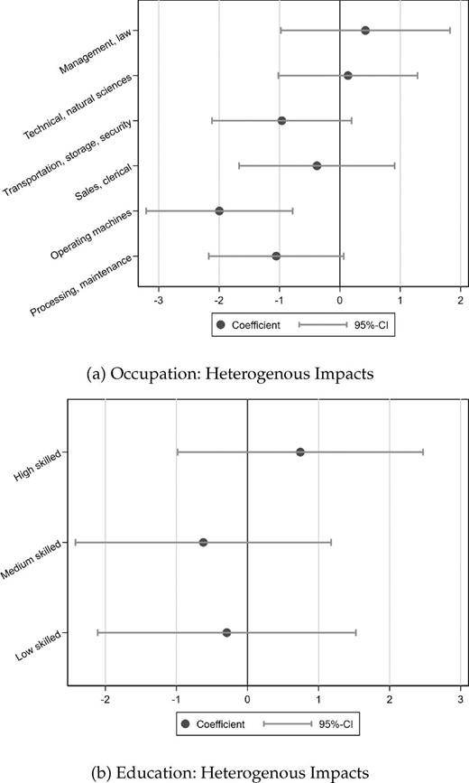

[Open in new tab](https://academic.oup.com/view-large/figure/325292995/jvab012fig3.jpg)Download slide

Heterogeneous earnings effects by occupation and education. The figures report the coefficients of interaction terms of Δ predicted robot exposure per 1,000 workers and dummies indicating the respective worker group. 2SLS IV regressions, where German robot exposure is instrumented with robot installations across industries in other high-income countries. The outcome variables are 100 × earnings (normalized by earnings in the base year) cumulated over the 20 years following the base year. In panel (a), occupations base on the definition of aggregate occupational fields by the German Federal Institute for Vocational Education and Training (BIBB) with the following modifications: Sales and clerical occupations are combined, and agriculture, mining, and construction (which would have a point estimate of zero with a huge standard error) are omitted. In panel (b), high skilled is defined as having a degree from a university or university of applied sciences, and medium skilled is defined as having a vocational training degree. All other educational levels are subsumed as low skilled. All regressions include the same full set of control variables as in Table 14. The confidence intervals are constructed from standard errors clustered by 20 ISIC Rev. 4 industries.

In panel A, for two occupation groups, the estimated impact is positive but small and not statistically significant at the conventional 5% level. These are managers and legal specialists, as well as occupations in the fields of technical science and natural science. This group encompasses, for example, all kinds of engineers as well as chemists. Automation through robots has arguably benefited these occupations, which are very highly skilled and heavily rely on cognitive-intensive tasks.

In the middle of the spectrum, with small and negative coefficients, one finds the point estimates for clerical/sales workers and a bundle of occupations, encompassing, for example, security and transportation workers. The common theme here is that the task set of those occupations is mostly non-routine and, hence, at least during the period we study, technically harder to automate. Interestingly, the rents from robots are seemingly passed on at higher rates to the set of skilled, technical occupations discussed in the preceding paragraph.

The next lines present the results for a set of occupations, which are suspected to be strongly exposed to replacement. Indeed, we find significant earnings losses mainly for machine operators. Industrial robots—by definition—do not require a human operator anymore but have the potential of conducting many production steps autonomously. Robots therefore directly substitute the task sets of this group. The point estimate here implies that a manufacturing worker at the third quartile of exposure sees an earnings reduction of around 41% of initial annual earnings, relative to a worker at the first quartile of exposure. A qualitatively similar finding is obtained for workers in processing and maintenance, but the effect size here is only a half of the effect for machine operators.

A second natural way to cut the data is to consider impacts across education groups, following an enormous literature investigating how technological change affects relative skill demand. In the German context, because of the prevalence of the apprenticeship system, it makes sense to split the population not just into two, but into three skill groups. In panel B, high skilled is defined as having a degree from a university or college and medium skilled is defined as having completed a vocational training degree. All other educational levels are subsumed as low skilled (i.e. high school graduates and high school dropouts). Completed apprenticeship is the typical profile for manufacturing workers in Germany, accounting for almost 75% of all individuals in the sample. A total of 16% are low skilled and 9% high skilled according to the classification.

## 7. Conclusion

Many people foresee a further rise of robots, artificial intelligence, and other automation technologies, which can potentially disrupt labor markets. The small but growing empirical literature on this topic, most importantly Acemoglu and Restrepo (2019) and Graetz and Michaels (2018), has documented the (negative) effects of industrial robots on employment and wages and (positive) impacts on productivity. Nevertheless, there has been little work on studying the adjustment processes of labor markets and its main actors (workers and firms) in response to new automation technologies. This paper has focused on Germany, whose manufacturing sector is among the most robotized ones in the world. Administrative labor market data provide us with a rare longitudinal perspective on how workers and firms have responded to the increase in automation that happened between 1994 and 2014.

The results paint a nuanced picture. They also point to a strong interaction with labor market institutions. Relatively strong protections for incumbent workers shift the incidence of job displacement on young workers and labor market entrants. In order to retain workers, whose task sets were automated, we observe a notable transition into new occupations and tasks at the same workplace. We find several pieces of evidence that these transitions contribute significantly to soften the blow of automation. Encouragingly, the data suggest that skill upgrading goes hand-in-hand with those transitions. Such skill upgrading is also observed for young workers and labor market entrants.

Labor market institutions are an important mediator of the effects of technological advances. How the next generation of advances in artificial intelligence, machine learning, and new manufacturing technologies will impact workers will also depend on the future design of these institutions. We believe these questions should be investigated with more empirical evidence on the interaction, but also theoretical work incorporating institutional aspects and the frictions inherent in labor markets.